# Electronic Cigarette and Youth

### What are the reasons youths have used ecigarettes? (Select one or more)

A. I have never tried an e-cigarette

B. Friend or family member used them

C. To try to quit using other tobacco products, such as cigarettes

D. They cost less than other tobacco products, such as cigarettes

E. They are easier to get than other tobacco products, such as cigarettes

F. Famous people on TV or in movies use them

G. They are less harmful than other forms of tobacco, such as cigarettes

H. They are available in flavors, such as mint, candy, fruit, or chocolate

I. They can be used in areas where other tobacco products, such as cigarettes, are not allowed

J. I used them for some other reason

As indicateds in the subtitles, this is a questions with several responses. Generally, this kind of data are very difficult to visualize. We will exam these data step by step.

First, we clean the data a little bit and create a new columns called `Q33` showing the response in a human reading way. And the filter `Q33A` as we only care about those have tried e-cigarettes.

```
## # A tibble: 7 x 10
##   Q33B  Q33C  Q33D  Q33E  Q33F  Q33G  Q33H  Q33I  Q33J  Q33
##   <chr> <chr> <chr> <chr> <chr> <chr> <chr> <chr> <chr> <chr>
## 1 B     <NA>  <NA>  <NA>  <NA>  <NA>  <NA>  <NA>  <NA>  B
## 2 <NA>  <NA>  <NA>  <NA>  <NA>  G     H     <NA>  J     GHJ
## 3 B     <NA>  <NA>  <NA>  <NA>  <NA>  H     <NA>  <NA>  BH
## 4 B     <NA>  <NA>  <NA>  <NA>  <NA>  <NA>  <NA>  <NA>  B
## 5 <NA>  <NA>  <NA>  <NA>  <NA>  G     <NA>  <NA>  <NA>  G
## 6 <NA>  <NA>  <NA>  <NA>  <NA>  <NA>  <NA>  <NA>  J     J
## 7 B     <NA>  <NA>  <NA>  <NA>  <NA>  <NA>  <NA>  <NA>  B
```

You know what? There are totally 159 different combination appears! But mathematically speaking, there could be 512 different choice at most. So, definitely, there are some patterns behind.

In the following plot, we only count the frequency of each choice without considering the combination. It if quite clear that choice B: Friend or family member used them is the major reasons for youth to try e-cigarettes. And the second is e-cigarettes are available in flavors, such as mint, candy, fruit, or chocolate. And then they are less harmful than other forms of tobacco, such as cigarettes if we do not consider other reasons, i.e. choice J. Health is not the major reason for youth to choice e-cigarettes!! And if only counts less than half of influence of friends and familys!!

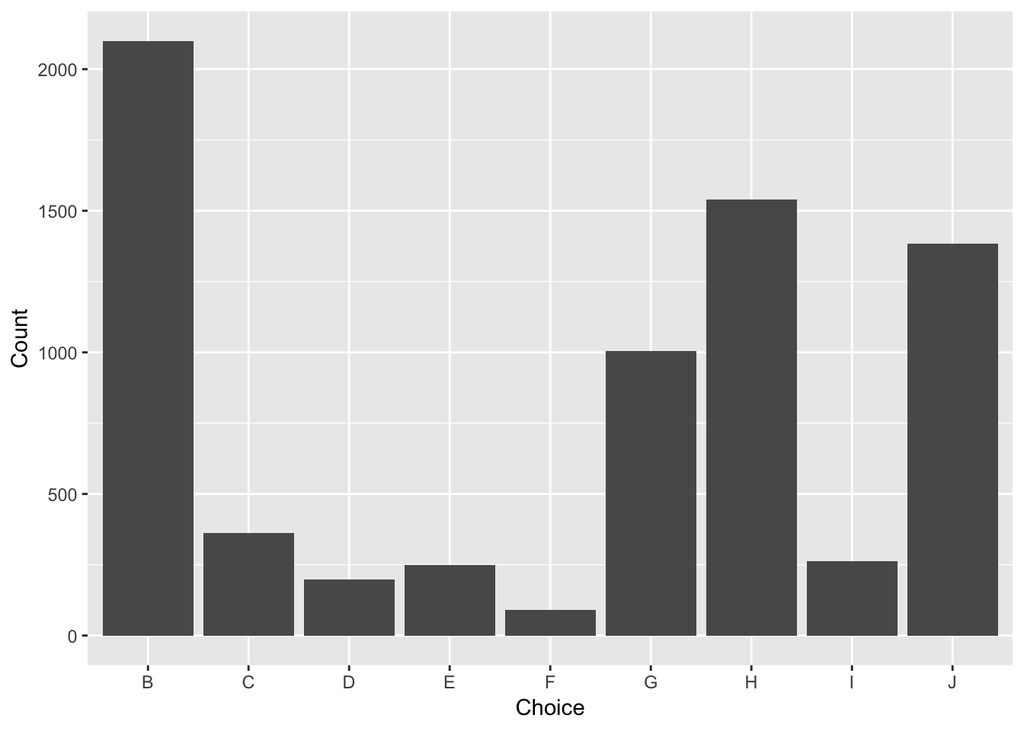

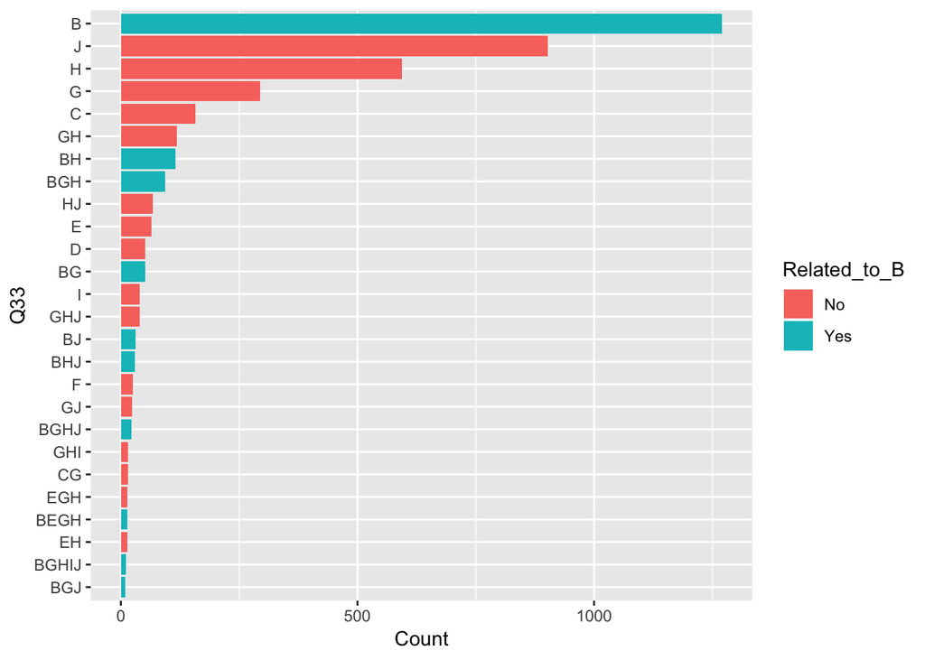

One thing we are interested in is how likely people become “addictive” after they try e-cigarettes once or twice and become regular smokers. We define “addictive” and “regular smokers” as thoses who spend more than two days to smoke e-cigarettes within 30 days. This question is addressed in two steps: 1) what is the percentage of regular smokers in the whole population? 2) what is the percentage of regular smokers among those who tried to smoke once or twice? And in order to give our readers a direct impression about the extent of addction, we compare with the data of ordinary cigarettes. The results are shown in the following several figures.

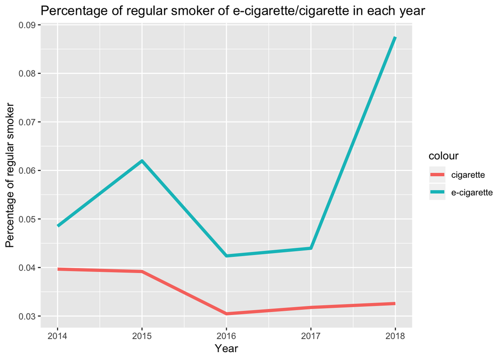

Another thing that worths to notices is that the percentage of regular e-cigarettes smokers is generally increases while the percentage of cigarettes is generally decreasing, suggesting e-cigarettes are becoming a trend among youth.

In addition to the investigations in the whole youth population, gender is also considered as an important factor: we would like to find out whether there is a huge difference between different genders with respect to smoking. Here is the result:

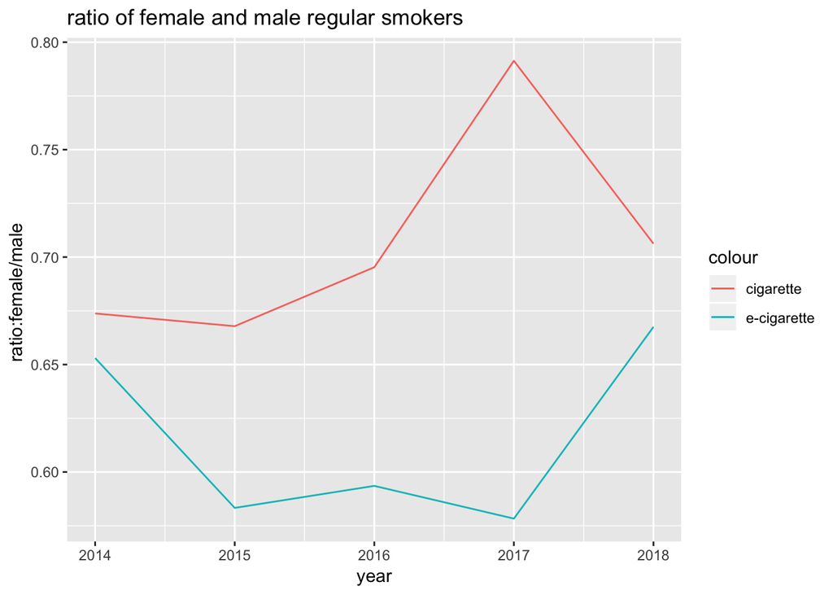

It seems that males are more “fashionable” in regards to smoking. There is higher female precentage in traditional smoking, than in the new-born e-cigarettes smoking.

To answer the second question, we plot the percentage of regular smokers among those who tried to smoke once or twice. Ther higher the percentage is, the more likely people sink into it.

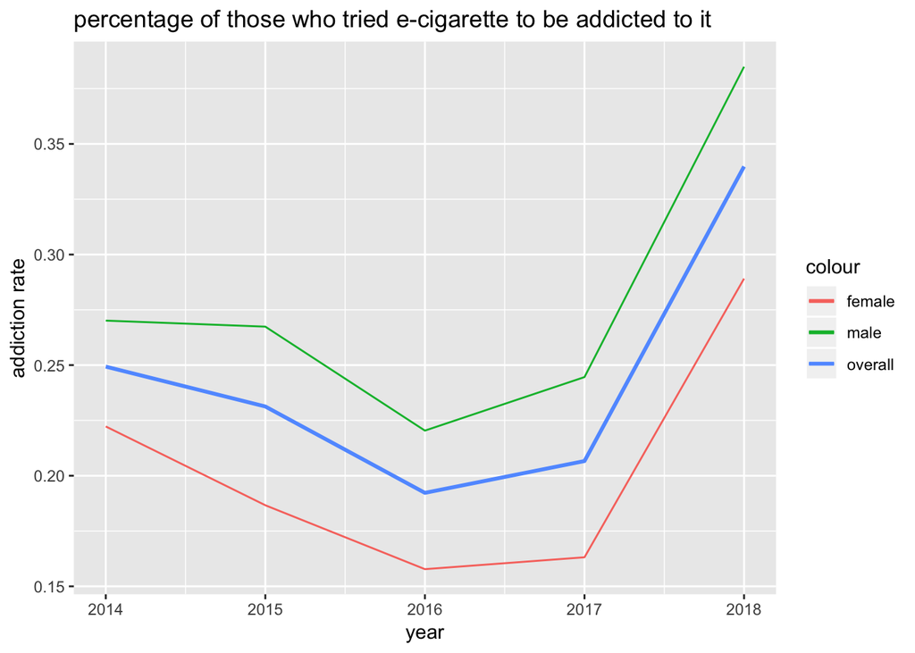

The figure above shows that 25% of those who are willing to try e-cigarettes turn out to be regular smokers. Tha explaination for this can be multiple: it is possible that in the beginning 1/4 of the triers are determined to be regular smokers. Or it is possible that e-cigarettes can attract 1/4 of the triers. Gender also plays a role in the process. Female are less likely to turn into a regular e-cigarette smoker than males.

As previously shown, e-cigarettes seem to become more and more popular among young people. Not only is it reflected in the percentage of regular smokers, but also reflected in the age when people try e-cigarettes for the first time.

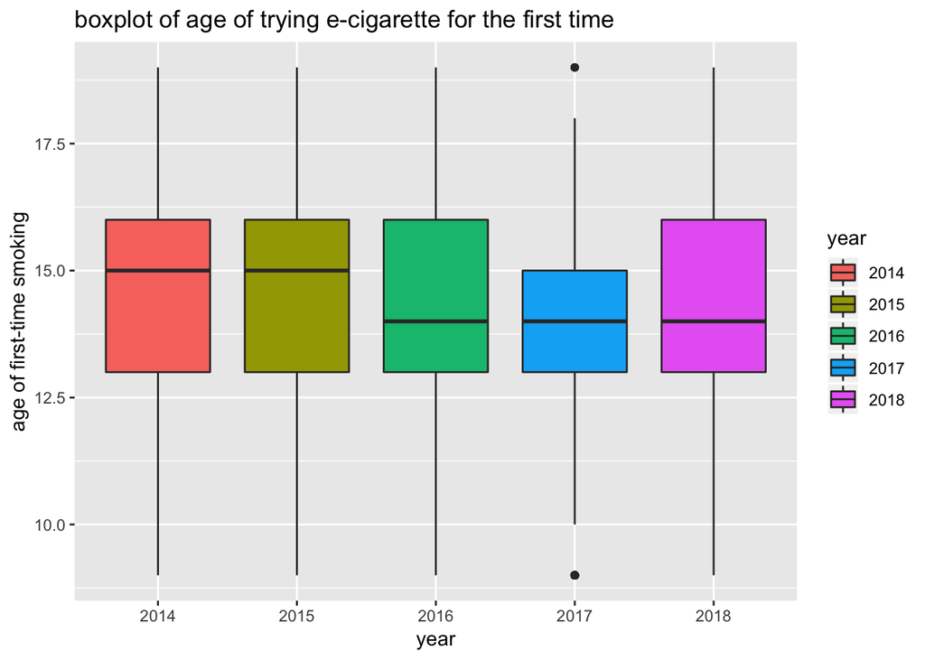

The figure above shows that the age when the youth try their first taste of e-cigarettes becomes younger. In the investigation in 2014, it happened at the age of 15. Now in 2018, it happens at the age of 14.

One one hand, we see the popularity of e-cigarettes among youth. On the other hand, the days people spend to use e-cigarettes is increasing. We suspect it is partially due to the popularity of e-cigarettes. One possibility is that when people realize e-cigarette is a fishionable thing, they may have less motive to restrain themselves from it. Another reason we can think of is that people with more years of smoking experience tend to smoke more often. E-cigarettes is a new thing, so the percentage of many-years smoker is still increasing.

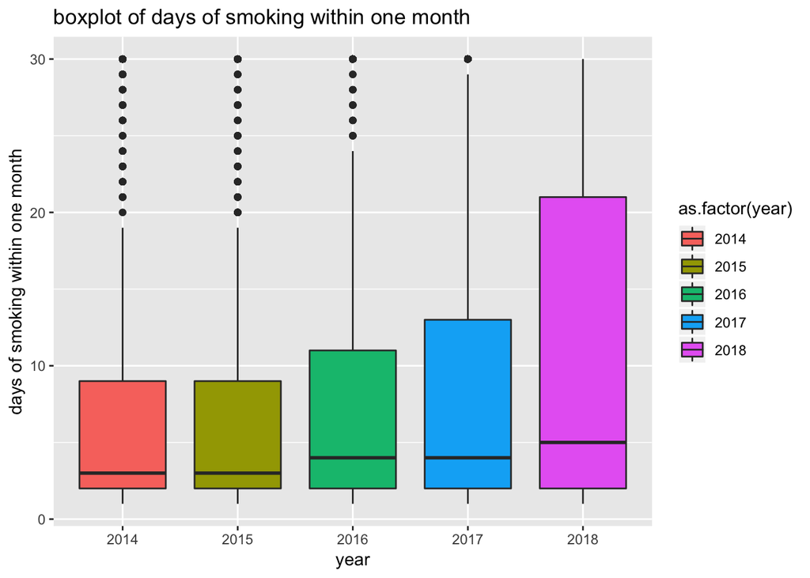

The questionair includs questions about advertisement in four kinds of media: internet, newspaper, supermarkets, TV. It asks how often do youth see advertisement of e-cigarette in those media. Five options are given: never, rarely, sometimes, most of the time, always.

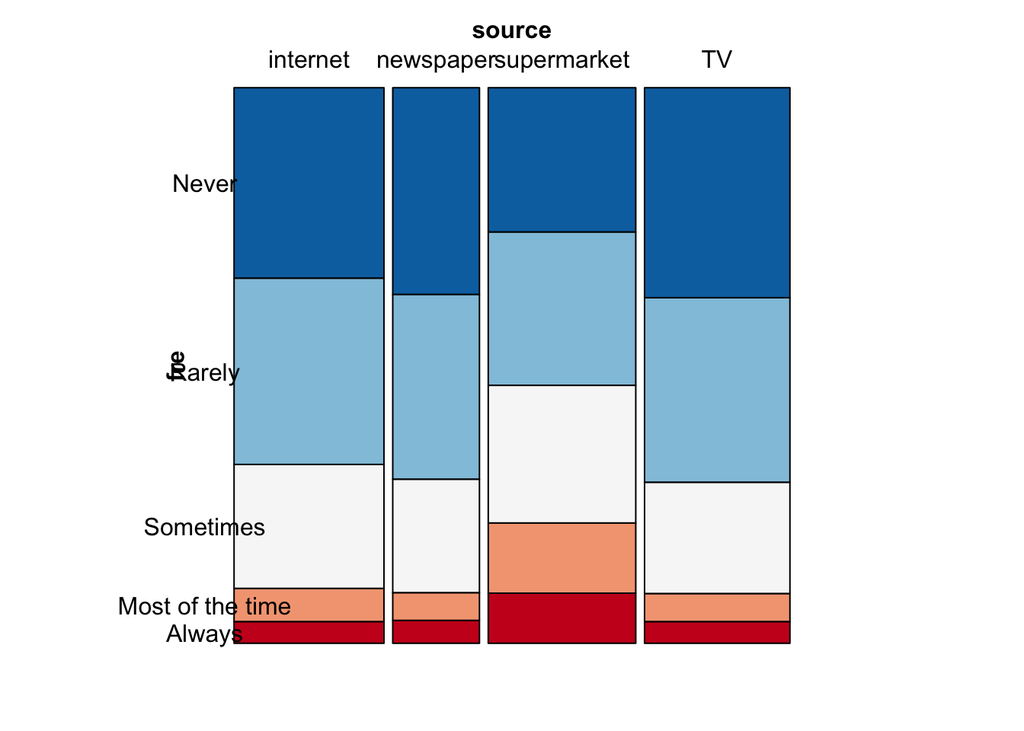

[interactive chart not shown]